# Elimination & Clearance Concepts Problem Set

Author

Vijay Ivaturi

# 1 “Thinking Inside the Box”

Given:

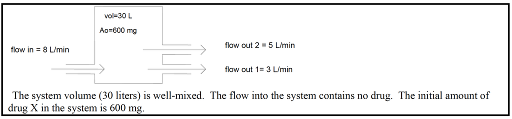

Figure 1: A box representing a well-mixed system with flow in and two flow out paths

- Flow in = 8 L/min
- Flow out 2 = 5 L/min
- Flow out 1 = 3 L/min
- Volume = 30 L
- Initial amount (A₀) = 600 mg

The system volume (30 liters) is well-mixed. The flow into the system contains no drug. The initial amount of drug X in the system is 600 mg.

1. What is the clearance of drug X in the above system? Give a definition of clearance using the relationship between rate and concentration. Is the clearance constant with time? Briefly explain.

```julia
# Your answer here
```

2. What is the rate of elimination from the system when 400 mg of the drug has been eliminated? Is the rate of elimination of drug from this system constant with time? What does the rate of elimination depend upon?

```julia
# Your answer here
```

3. If flow out 1 represents elimination by the kidney and flow out 2 represents the elimination of drug X by liver metabolism, determine the following:
- 1. the rate of metabolism when 500 mg of the drug has been eliminated
- 2. the rate of renal excretion at the time point equal to one half-life of the drug

```julia
# Your answer here
```

4. Estimate the half-life of drug X in the above system. Would the half-life change if the volume of distribution decreased to 15 liters? Would the half-life change if the metabolic clearance doubled? If the half-life changes for either of these situations, calculate the new half-life.

```julia
# Your answer here
```

5. Given the above system, quantitatively draw a concentration versus time profile on semilog graph paper. (N.B. cover at least three half-lives with the scale on the x-axis)

```julia
# Your answer here
```

# 2 “Organ Clearance”

Given the following scheme:

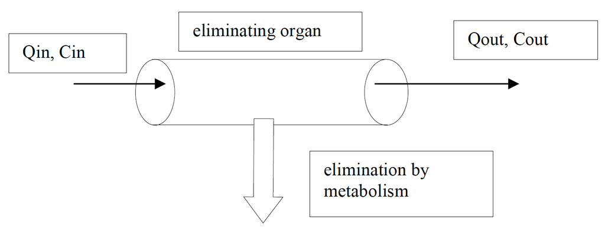

Figure 2: A box representing a well-mixed system with flow in and one flow out path

The blood flow into this organ is 1000 ml/min (Qin). A constant concentration of 5 mg/liter enters the organ (Cin). The sole mechanism of elimination by this organ is metabolism, and, in a one hour period at steady state, the organ metabolizes 90 milligrams of the drug. The blood flow rates into and out of the organ are equal. The volume of distribution of this drug is 75 liters.

1. What is the extraction ratio of this eliminating organ?

```julia
# Your answer here
```

2. What is the steady state concentration leaving the organ to return to the blood pool? (i.e., Cout)

```julia
# Your answer here
```

3. Calculate the organ clearance. Given that this organ clearance represents the only means of elimination from the body, calculate the half-life.

```julia
# Your answer here
```

4. What would be the rate of metabolism if the concentration entering the organ was 25 mg/liter?

```julia
# Your answer here
```

5. Calculate the change in organ clearance when the volume of distribution of the drug doubles to 150 liters.

```julia
# Your answer here
```

# 3 Four Practice Problems (Thinking Inside the Box)

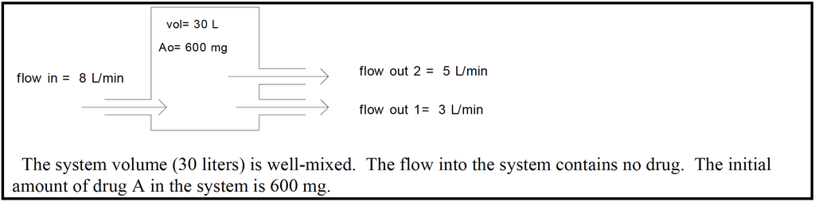

Figure 3: A box representing a well-mixed system with flow in and two flow out paths

## 3.1 Problem 1

Given:

- Flow in = 8 L/min
- Flow out 2 = 5 L/min
- Flow out 1 = 3 L/min
- Volume = 30 L
- Initial amount (A₀) = 600 mg

The system volume (30 liters) is well-mixed. The flow into the system contains no drug. The initial amount of drug A in the system is 600 mg.

1. What is the clearance of drug A in the above system? Give a definition of clearance using the relationship between rate and concentration. Is the clearance constant with time? Briefly explain.

```julia
# Your answer here
```

2. What is the rate of elimination from the system when 300 mg of the drug has been eliminated? Is the rate of elimination of drug from this system constant with time? What does the rate of elimination depend upon?

```julia
# Your answer here
```

3. If flow out 1 represents elimination by the kidney and flow out 2 represents the elimination of drug A by liver metabolism, determine the following:
- 1. the total body clearance when there is complete liver failure.
- 2. the rate of metabolism when 500 mg of the drug has been eliminated (under normal liver function).

```julia
# Your answer here
```

4. Estimate the half-life of drug A in the above system. Would the half-life change if the volume of distribution decreased to 10 liters? Would the half-life change if the renal clearance doubled? If the half-life changes for either of these situations, calculate the new half-life. If the half-life changes when the volume decreases, explain why.

```julia
# Your answer here
```

5. Given the above system, quantitatively draw a concentration versus time profile on semilog graph paper. (cover at least three half-lives with the scale on the x-axis)

```julia
# Your answer here
```

## 3.2 Problem 2

Given:

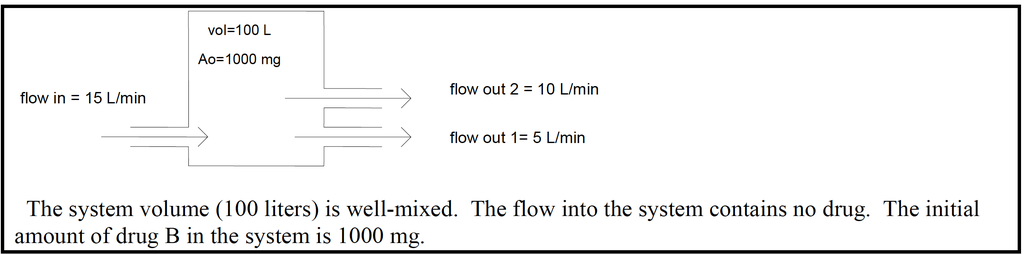

Figure 4: A box representing a well-mixed system with flow in and two flow out paths

- Flow in = 15 L/min
- Flow out 2 = 10 L/min
- Flow out 1 = 5 L/min
- Volume = 100 L
- Initial amount (A₀) = 1000 mg

The system volume (100 liters) is well-mixed. The flow into the system contains no drug. The initial amount of drug B in the system is 1000 mg.

1. What is the clearance of drug B in the above system? Give a definition of clearance using the relationship between rate and concentration. Is the clearance constant with time? Briefly explain.

```julia
# Your answer here
```

2. What is the rate of elimination from the system when 100 mg of the drug has been eliminated? Is the rate of elimination of drug from this system constant with time? What does the rate of elimination depend upon?

```julia
# Your answer here
```

3. If flow out 1 represents elimination by the kidney and flow out 2 represents the elimination of drug B by liver metabolism, determine the following:
- 1. the total body clearance when there is complete renal failure.
- 2. the rate of metabolism when 750 mg of the drug has been eliminated (under normal liver function).

```julia
# Your answer here
```

4. Estimate the half-life of drug B in the above system. Would the half-life change if the volume of distribution increased to 200 liters? Would the half-life change if the renal clearance doubled? If the half-life changes for either of these situations, calculate the new half-life.

```julia
# Your answer here
```

5. Given the above system, quantitatively draw a concentration versus time profile on semilog graph paper. (cover at least three half-lives with the scale on the x-axis)

```julia
# Your answer here
```

## 3.3 Problem 3

Given:

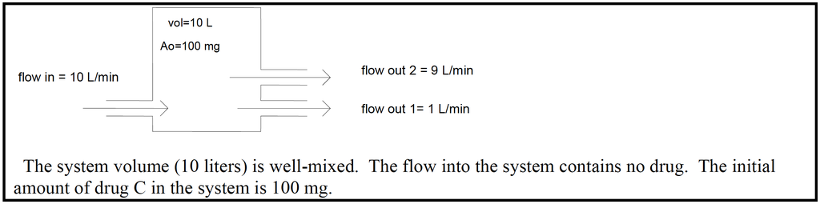

Figure 5: A box representing a well-mixed system with flow in and two flow out paths

- Flow in = 10 L/min
- Flow out 2 = 9 L/min
- Flow out 1 = 1 L/min
- Volume = 10 L
- Initial amount (A₀) = 100 mg

The system volume (10 liters) is well-mixed. The flow into the system contains no drug. The initial amount of drug C in the system is 100 mg.

1. What is the clearance of drug C in the above system? Give a definition of clearance using the relationship between rate and concentration. Is the clearance constant with time? Briefly explain.

```julia
# Your answer here
```

2. What is the rate of elimination from the system when 90 mg of the drug has been eliminated? Is the rate of elimination of drug from this system constant with time? What does the rate of elimination depend upon?

```julia
# Your answer here
```

3. If flow out 1 represents elimination by the kidney and flow out 2 represents the elimination of drug C by liver metabolism, determine the following:
- 1. the total body clearance when there is complete liver failure.
- 2. the rate of renal excretion when 30 mg of the drug has been eliminated (under normal liver function).

```julia
# Your answer here
```

4. Estimate the half-life of drug C in the above system. Would the half-life change if the volume of distribution decreased to 5 liters? Would the half-life change if the metabolic clearance doubled? If the half-life changes for either of these situations, calculate the new half-life.

```julia
# Your answer here
```

5. Given the above system, quantitatively draw a concentration versus time profile on semilog graph paper. (cover at least three half-lives with the scale on the x-axis)

```julia
# Your answer here
```

## 3.4 Problem 4

Given:

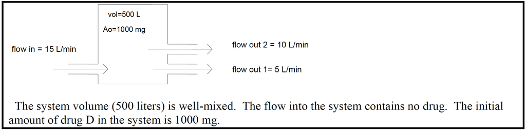

Figure 6: A box representing a well-mixed system with flow in and two flow out paths

- Flow in = 15 L/min
- Flow out 2 = 10 L/min
- Flow out 1 = 5 L/min
- Volume = 500 L
- Initial amount (A₀) = 1000 mg

The system volume (500 liters) is well-mixed. The flow into the system contains no drug. The initial amount of drug D in the system is 1000 mg.

1. What is the clearance of drug D in the above system? Give a definition of clearance using the relationship between rate and concentration. Is the clearance constant with time? Briefly explain.

```julia
# Your answer here
```

2. What is the rate of elimination from the system when 600 mg of the drug has been eliminated? Is the rate of elimination of drug from this system constant with time? What does the rate of elimination depend upon?

```julia
# Your answer here
```

3. If flow out 1 represents elimination by the kidney and flow out 2 represents the elimination of drug D by liver metabolism, determine the following:
- 1. the total body clearance when there is complete renal failure.
- 2. the rate of metabolism when 500 mg of the drug has been eliminated (under normal liver function).

```julia
# Your answer here
```

4. Estimate the half-life of drug D in the above system. Would the half-life change if the volume of distribution decreased to 50 liters? Would the half-life change if the metabolic clearance doubled? If the half-life changes for either of these situations, calculate the new half-life. Why did the half-life decrease when the volume decreased?

```julia
# Your answer here
```

5. Given the above system, quantitatively draw a concentration versus time profile on semilog graph paper. (cover at least three half-lives with the scale on the x-axis)

```julia
# Your answer here
```

# 4 Some Ideas About Organ Clearance

## 4.1 Considering the organ clearance scheme, answer the following questions:

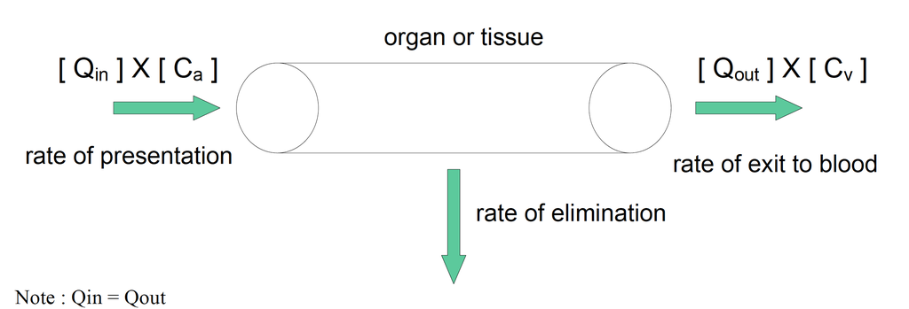

Figure 7: A box representing a well-mixed system with flow in and one flow out path

Note: Qin = Qout

1. Calculate the extraction ratio if the Qin is 1 liter/min and the arterial concentration is 1 mg/L and the venous concentration is 0.5 mg/L.

```julia
# Your answer here
```

2. Calculate the organ clearance if the Qin is 1 liter/min and the arterial concentration is 1 mg/L and the venous concentration is 0.5 mg/L.

```julia
# Your answer here
```

3. Calculate the organ clearance if the Qin is 2 liter/min and the arterial concentration is 1 mg/L and the venous concentration is 0.5 mg/L.

```julia
# Your answer here
```

4. Calculate the organ clearance if the Qin is 1.5 liter/min and the arterial concentration is 1 mg/L and the venous concentration is 0.5 mg/L.

```julia
# Your answer here
```

5. Calculate the organ clearance if the Qin is 1 liter/min and the arterial concentration is 1 mg/L and the venous concentration is 0.9 mg/L.

```julia
# Your answer here
```

6. Calculate the organ clearance if the Qin is 1 liter/min and the arterial concentration is 1 mg/L and the venous concentration is 0.1 mg/L.

```julia
# Your answer here
```

7. Calculate the rate of elimination if the Qin is 1 liter/min and the arterial concentration is 1 mg/L and the venous concentration is 0.5 mg/L.

```julia
# Your answer here
```

8. Calculate the rate of elimination if the Qin is 2 liter/min and the arterial concentration is 1 mg/L and the venous concentration is 0.5 mg/L.

```julia
# Your answer here
```

9. Calculate the rate of elimination if the Qin is 0.5 liter/min and the arterial concentration is 1 mg/L and the venous concentration is 0.5 mg/L.

```julia
# Your answer here
```

10. Calculate the rate of elimination if the Qin is 1 liter/min and the arterial concentration is 2 mg/L and the venous concentration is 0.5 mg/L.

```julia
# Your answer here
```

11. Calculate the concentration entering the eliminating organ if the rate of elimination is 60 mg/hr, and the Qin is 1 liter/min and the Cout is 1 mg/L.

```julia
# Your answer here
```

12. Calculate the concentration entering the eliminating organ if the rate of elimination is 60 mg/hr, and the Qin is 1 liter/min and the Cout is 0.5 mg/L.

```julia
# Your answer here
```

13. Calculate the concentration entering the eliminating organ if the rate of elimination is 120 mg/hr, and the Qin is 1 liter/min and the Cout is 1 mg/L.

```julia
# Your answer here
```

14. Calculate the concentration entering the eliminating organ if the rate of elimination is 200 mg/hr, and the Qin is 1 liter/min and the Cout is 0.1 mg/L.

```julia
# Your answer here
```

15. Calculate the concentration leaving the eliminating organ if the rate of elimination is 100 mg/hr, and the Qin is 1 liter/min and the Cin is 2 mg/L.

```julia
# Your answer here
```

## 4.2 Considering the organ clearance scheme, answer the following questions:

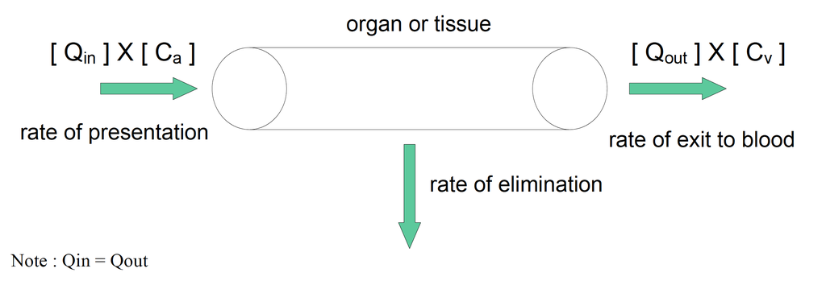

Figure 8: A box representing a well-mixed system with flow in and one flow out path

Note: Qin = Qout

1. Calculate the organ clearance when the extraction ratio is 0.5 and the Qin is 1.5 liters per minute.

```julia
# Your answer here
```

2. Calculate the organ clearance when the extraction ratio is 0.75 and the Qin is 1.5 liters per minute.

```julia
# Your answer here
```

3. Calculate the organ clearance when the extraction ratio is 0.1 and the Qin is 2.5 liters per minute.

```julia
# Your answer here
```

4. What is the maximum value that an extraction ratio can have? Why?

```julia
# Your answer here
```

5. What is the minimum value for an extraction ratio?

```julia
# Your answer here
```

6. If the flow into an organ is 1 liter per minute, what is the maximum organ clearance? Why?

```julia
# Your answer here
```

7. Consider an organ clearance of 2 liters per minute and the flow to that same organ is 2.2 liters per minute, would these data predict a high or low extraction ratio?

```julia
# Your answer here
```

8. Define the extraction ratio.

```julia
# Your answer here
```

9. Drug distributes to a particular non-eliminating organ (organ X) (blood flow to organ X is 0.25 liter per minute). Calculate the organ clearance for organ X.

```julia
# Your answer here
```

10. Drug distributes to a particular eliminating organ (organ Y) (blood flow to organ Y is 1.2 liter per minute). Calculate the organ clearance for organ Y. (discuss the assumptions you made in your calculation)

```julia
# Your answer here
```

# 5 Some Basic Concepts Practice Questions:

1. If the concentration in the plasma is 10 mg/L and the plasma clearance is 10 L/hr, what is the rate of elimination of drug?

```julia
# Your answer here
```

2. If the concentration in the plasma is 50 mg/L and the plasma clearance is 1 L/hr, what is the rate of elimination of drug?

```julia
# Your answer here
```

3. If the concentration in the plasma is 1 μg/L and the plasma clearance is 20 ml/min, what is the rate of elimination of drug in mg/hr?

```julia
# Your answer here
```

4. If the concentration in the plasma is 10 mg/ml and the plasma clearance is 5 L/min, what is the rate of elimination of drug?

```julia
# Your answer here
```

5. If the concentration in the plasma is 10 mg/L and the rate of elimination of drug is 10 mg/hr, what is the plasma clearance of the drug?

```julia
# Your answer here
```

6. If the concentration in the plasma is 1 mg/L and the rate of elimination of drug is 10 μg/min, what is the plasma clearance of the drug?

```julia
# Your answer here
```

7. If the concentration in the plasma is 1.5 μg/L and the rate of elimination of drug is 10 μg/hr, what is the plasma clearance of the drug?

```julia
# Your answer here
```

8. If the concentration in the plasma is 8 mg/L and the rate of elimination of drug is 100 mg/hr, what is the plasma clearance of the drug?

```julia
# Your answer here
```

9. If the volume of distribution of a drug is 1 liter and the total clearance is 1 L/hr, what is the half-life?

```julia
# Your answer here
```

10. If the volume of distribution of a drug is 10 liters and the total clearance is 1 L/hr, what is the half-life?

```julia
# Your answer here
```

11. If the volume of distribution of a drug is 100 liters and the total clearance is 1 L/hr, what is the half-life?

```julia
# Your answer here
```

12. If the volume of distribution of a drug is 1000 liters and the total clearance is 1 L/hr, what is the half-life?

```julia
# Your answer here
```

13. If the volume of distribution of a drug is 100 liters and the total clearance is 0.1 L/hr, what is the half-life?

```julia
# Your answer here
```

14. If the volume of distribution of a drug is 100 liters and the total clearance is 1 L/hr, what is the half-life?

```julia
# Your answer here
```

15. If the volume of distribution of a drug is 100 liters and the total clearance is 10 L/hr, what is the half-life?

```julia
# Your answer here
```

16. If the volume of distribution of a drug is 100 liters and the total clearance is 100 L/hr, what is the half-life?

```julia
# Your answer here
```

17. If the volume of distribution increases and the clearance remains constant, what happens to the half-life?

```julia
# Your answer here
```

18. If the volume of distribution decreases and the clearance remains constant, what happens to the half-life?

```julia
# Your answer here
```

19. If the clearance increases and the volume of distribution remains constant, what happens to the half-life?

```julia
# Your answer here
```

20. If the clearance decreases and the volume of distribution remains constant, what happens to the half-life?

```julia
# Your answer here
```

21. If the volume of distribution increases and the clearance remains constant, what happens to the initial rate of elimination?

```julia
# Your answer here
```

22. If the volume of distribution decreases and the clearance remains constant, what happens to the initial rate of elimination?

```julia
# Your answer here
```

23. If the clearance increases and the volume of distribution remains constant, what happens to the initial rate of elimination?

```julia
# Your answer here
```

24. If the clearance decreases and the volume of distribution remains constant, what happens to the initial rate of elimination?

```julia
# Your answer here
```